# 20240407_3 slides

## Categorical Variables

### IHas anyone had a song on the charts longer than the longest Beatles' song ever on the charts?

#### I'll make two categories: The Beatles song on the charts the longest versus the Non-Beatles song on the charts the longest.

##### First, isolate the Beatles data in their own dataframe and all other artists in a different one to compare easily. ##### I'll also group the ROW df by performer & title in case there are any songs that released by more than one artist (covers) and then sort both dfs by wks_on_chart in descending order.

```python
df2 = pd.read_csv('hot-100-current.csv')
max2 = df2.groupby(['performer','title'],as_index=False)['wks_on_chart'].max()
print (max2)
```

```
                                               performer  \
0                                        "Groove" Holmes
1                                        "Groove" Holmes
2                                 "Little" Jimmy Dickens
3                                        "Pookie" Hudson
4                                    "Weird Al" Yankovic
...                                                  ...
31047                            will.i.am & Nicki Minaj
31048                  will.i.am Featuring Justin Bieber
31049   will.i.am Featuring Mick Jagger & Jennifer Lopez
31050                    will.i.am Featuring Miley Cyrus
31051  will.i.am Featuring Miley Cyrus, French Montan...

                                           title  wks_on_chart
0                                          Misty            11
1                               What Now My Love             3
2      May The Bird Of Paradise Fly Up Your Nose            10
3                                  I Know I Know             1
4                                 Amish Paradise            16
...                                          ...           ...
31047                               Check It Out            15
31048                                 #thatPOWER            16
31049                   T.H.E (The Hardest Ever)             8
31050                                  Fall Down             1
31051                             Feelin' Myself             2

[31052 rows x 3 columns]
```

```python
# First question; has any title by anyone surpassed the beatles longest running title?
max3 = max2.sort_values(by=['wks_on_chart'], ascending=False)
print (max3)
# wow, yes! there's been a lot of them!
```

```
                                    performer                 title  \
10432                           Glass Animals            Heat Waves
28565                              The Weeknd       Blinding Lights
11692                         Imagine Dragons           Radioactive
416                                AWOLNATION                  Sail
7823                                 Dua Lipa            Levitating
...                                       ...                   ...
22214                            Robin Thicke          Get Her Back
28645  The White Buffalo & The Forest Rangers  Come Join The Murder
10589                               Glee Cast        Sweet Caroline
10590                               Glee Cast            Take A Bow
9842                                   Future         Super Trapper

       wks_on_chart
10432            91
28565            90
11692            87
416              79
7823             77
...             ...
22214             1
28645             1
10589             1
10590             1
9842              1

[31052 rows x 3 columns]
```

```python
# wow so see, what's with the come together/something line? why isn't it hashed with got to get you into my life, which is also 16 weeks?
# remember to look it up online later - stay on target!
maxes2 = max3[max3['performer']=='The Beatles']
print (maxes2)
```

```
         performer                             title  wks_on_chart
25563  The Beatles                   Twist And Shout            26
25525  The Beatles                          Hey Jude            19
25514  The Beatles           Come Together/Something            16
25522  The Beatles       Got To Get You Into My Life            16
25551  The Beatles                     She Loves You            15
...            ...                               ...           ...
25565  The Beatles                      What Goes On             2
25539  The Beatles                      Now And Then             2
25561  The Beatles                   There's A Place             1
25559  The Beatles                   The Inner Light             1
25533  The Beatles  I'm Happy Just To Dance With You             1

[66 rows x 3 columns]
```

```python
# max3.iloc[0].wks_on_chart
allmaxweeks = max3.iloc[0].wks_on_chart
allmaxperformer = max3.iloc[0].performer
allmaxtitle = max3.iloc[0].title
print(allmaxweeks)
print(allmaxperformer)
print(allmaxtitle)
```

```
91
Glass Animals
Heat Waves
```

```python
maxes2.iloc[0]
bmaxweeks = maxes2.iloc[0].wks_on_chart
#bmaxperformer = maxes2.iloc[0].performer
bmaxtitle = maxes2.iloc[0].title
print(bmaxweeks)
print(bmaxtitle)
```

```
26
Twist And Shout
```

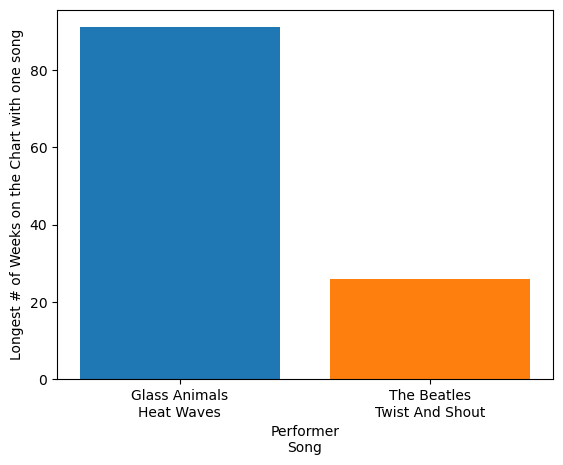

```python
#now a bar chart to show this
#maybe a trend line/time series chart to show in which year(s) these 1260 songs happened during

import matplotlib.pyplot as plt

plt.xlabel("Performer\n"+"Song")
plt.ylabel("Longest # of Weeks on the Chart with one song")
plt.bar(allmaxperformer+"\n"+allmaxtitle, allmaxweeks)
plt.bar('The Beatles'+"\n"+bmaxtitle, bmaxweeks);
```

# Numerical Variables

#### Since the Beatles hit #1 in the UK, how many other bands have accomplished that feat? How many other songs have hit #1?

#### To find out, do a distribution of peak position by title.

#### But first, I'm curious about how many number one songs are in the file.

```python
df2[df2['peak_pos']==1].count()
```

```
chart_week      17762
current_week    17762
title           17762
performer       17762
last_week       17671
peak_pos        17762
wks_on_chart    17762
dtype: int64
```

looks like there's a total of 10746 artists in the file Let me confirm there are NaNs in the data by looking at one perfomer who as more than one week on the chart and remind myself what the original dataframe I loaded up looks like

```python
df = df[df['performer'] == 'The Beatles']
print (df)
# taking a look at how jupyter nb renders print statements versus real-time return rendering
# print looks blocky and old-school font
```

```
        chart_week  current_week                     title    performer  \
9806    2023-11-18             7              Now And Then  The Beatles
9975    2023-11-25            76              Now And Then  The Beatles
39144   1964-01-18            45  I Want To Hold Your Hand  The Beatles
39202   1964-01-25             3  I Want To Hold Your Hand  The Beatles
39268   1964-01-25            69             She Loves You  The Beatles
...            ...           ...                       ...          ...
339458  1976-12-04            59        Ob-la-di, Ob-la-da  The Beatles
339548  1976-12-11            49        Ob-la-di, Ob-la-da  The Beatles
339648  1976-12-18            49        Ob-la-di, Ob-la-da  The Beatles
339770  1976-12-25            71        Ob-la-di, Ob-la-da  The Beatles
339870  1977-01-01            71        Ob-la-di, Ob-la-da  The Beatles

        last_week  peak_pos  wks_on_chart
9806          0.0         7             1
9975          7.0         7             2
39144         NaN        45             1
39202        45.0         3             2
39268         NaN        69             1
...           ...       ...           ...
339458       69.0        59             3
339548       59.0        49             4
339648       49.0        49             5
339770       49.0        49             6
339870       71.0        49             7

[587 rows x 7 columns]
```

```python
dfp=df.groupby(['performer'],as_index=False).count()
dfp
# just typing the var name instead renders better in non-command line font than using print
```

|  | performer | chart_week | current_week | title | last_week | peak_pos | wks_on_chart |
| --- | --- | --- | --- | --- | --- | --- | --- |
| 0 | The Beatles | 587 | 587 | 587 | 521 | 587 | 587 |

```python
enmasse0
# here's all-the-artists' recordset for the summed up "bad" version of the amount of weeks on the chart for performer
# b/c it used sum in the group by in stead of count
# reviewing the font again too
# just wanted to pull up a var from way above instead of in same cell to see if it would make diff which it didn't
```

|  | performer | wks_on_chart |
| --- | --- | --- |
| 8667 | Taylor Swift | 17117 |
| 6443 | Morgan Wallen | 12151 |
| 3893 | Imagine Dragons | 11125 |
| 2716 | Ed Sheeran | 10945 |
| 9788 | The Weeknd | 9828 |
| ... | ... | ... |
| 5387 | Lil Baby, Lil Durk & Young Thug | 1 |
| 9988 | Tony Bennett & Amy Winehouse | 1 |
| 5397 | Lil Durk & Chief Wuk | 1 |
| 8577 | T-Pain Featuring Rick Ross | 1 |
| 5503 | Lil Wayne Featuring Snoop Dogg | 1 |

10746 rows × 2 columns

```python
en0=enmasse0[enmasse0['performer']=='"Little" Jimmy Dickens']
en0
# similar test as above, but setting var in same cell
```

|  | performer | wks_on_chart |
| --- | --- | --- |
| 1 | "Little" Jimmy Dickens | 55 |

```python
enmasse = df.groupby(['performer'],as_index=False)['wks_on_chart'].sum()
# print (df)
enmasse.head()

##wow - has anyone beat that!?? Are there any othr groups that have had more songs have more weeks on the chart?

#actually this isn't right either, b/c of the summing instead of counting
```

|  | performer | wks_on_chart |
| --- | --- | --- |
| 0 | The Beatles | 3551 |

So now I wind down the exploratory exercises and start getting down to brass tacks to group the data properly to get the correct amount of song weeks that aren't inflated by using sum like above

# next maybe do all bands grouped by title and sum(max(wks_on_chart)) then sort by desc sum(max(wks_on_chart))

MISSION (Business Problem): Now I can find out how many songs that enter billboard 100 equal Beatles peak_pos #1 First, let me see the distribution of the max peak chart positions for each performer/song record, just to see what the shape is like -- i would predict it is a long tail to the left so neg skewness since it is harder I get a distribution of peak_pos which is a histogram since it is numeric data or is is a bar chart since ranks may be categorical -- or does it matter except for spacing no that's not what I do...but I play around anyway in the next cell

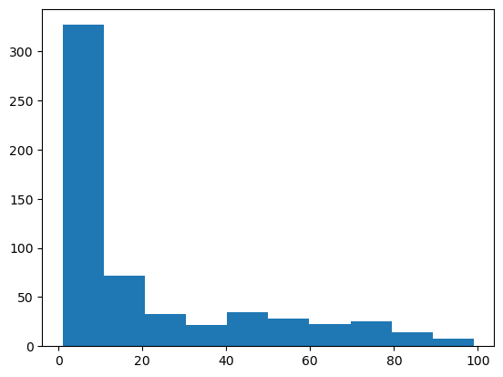

```python
plt.hist(x='peak_pos', data=df);
```

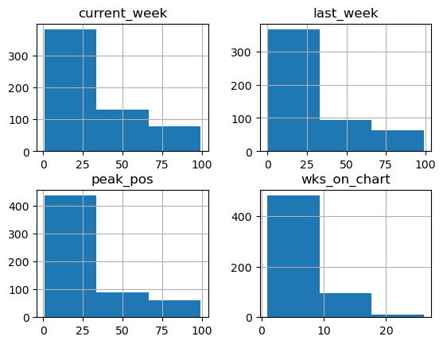

```python
#ok well then will this work?
#plt.hist(max3['peak_pos'])
df.hist(bins=3);
```

```python
max_wks_peak_all = df2.groupby(['performer', 'title'], as_index=False).agg({'wks_on_chart': 'max', 'peak_pos': 'max'})
max_wks_peak_all
```

|  | performer | title | wks_on_chart | peak_pos |
| --- | --- | --- | --- | --- |
| 0 | "Groove" Holmes | Misty | 11 | 100 |
| 1 | "Groove" Holmes | What Now My Love | 3 | 98 |
| 2 | "Little" Jimmy Dickens | May The Bird Of Paradise Fly Up Your Nose | 10 | 90 |
| 3 | "Pookie" Hudson | I Know I Know | 1 | 96 |
| 4 | "Weird Al" Yankovic | Amish Paradise | 16 | 65 |
| ... | ... | ... | ... | ... |
| 31047 | will.i.am & Nicki Minaj | Check It Out | 15 | 78 |
| 31048 | will.i.am Featuring Justin Bieber | #thatPOWER | 16 | 42 |
| 31049 | will.i.am Featuring Mick Jagger & Jennifer Lopez | T.H.E (The Hardest Ever) | 8 | 36 |
| 31050 | will.i.am Featuring Miley Cyrus | Fall Down | 1 | 58 |
| 31051 | will.i.am Featuring Miley Cyrus, French Montan... | Feelin' Myself | 2 | 96 |

31052 rows × 4 columns

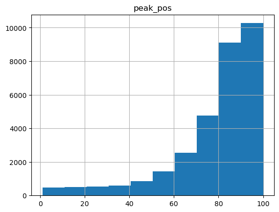

```python
max_wks_peak_all.hist('peak_pos');
```

yep, it looks like i thought it would

```python
# what is the average peak_pos and average wks_on_chart for entire file (all title/band combos)
max_wks_peak_all.describe()
```

|  | wks_on_chart | peak_pos |
| --- | --- | --- |
| count | 31052.000000 | 31052.000000 |
| mean | 11.011883 | 79.201984 |
| std | 8.514665 | 20.461379 |
| min | 1.000000 | 1.000000 |
| 25% | 4.000000 | 73.000000 |
| 50% | 9.000000 | 85.000000 |
| 75% | 16.000000 | 93.000000 |
| max | 91.000000 | 100.000000 |

```python
#so the average peak position of a band/title combo on the charts is

max_peak_pos_mean = max_wks_peak_all.agg(x=('peak_pos','mean'))
max_wks_peak_all.agg(x=('peak_pos','mean'))
```

|  | peak_pos |
| --- | --- |
| x | 79.201984 |

```python
type(max_peak_pos_mean)
```

```
pandas.core.frame.DataFrame
```

```python
int(max_peak_pos_mean['peak_pos'])
#or
```

```
79
```

```python
int(max_peak_pos_mean.iloc[0,0])
```

```
79
```

```python
#ax_peak_pos_mean = max_peak_pos_mean.to_numpy()
#max_peak_pos_mean
#no this won't work - i need an int
```

```python
#max_peak_pos_mean = max_peak_pos_mean.to_numpy()
#max_peak_pos_mean
```

```python
max_wks_peak_all
```

|  | performer | title | wks_on_chart | peak_pos |
| --- | --- | --- | --- | --- |
| 0 | "Groove" Holmes | Misty | 11 | 100 |
| 1 | "Groove" Holmes | What Now My Love | 3 | 98 |
| 2 | "Little" Jimmy Dickens | May The Bird Of Paradise Fly Up Your Nose | 10 | 90 |
| 3 | "Pookie" Hudson | I Know I Know | 1 | 96 |
| 4 | "Weird Al" Yankovic | Amish Paradise | 16 | 65 |
| ... | ... | ... | ... | ... |
| 31047 | will.i.am & Nicki Minaj | Check It Out | 15 | 78 |
| 31048 | will.i.am Featuring Justin Bieber | #thatPOWER | 16 | 42 |
| 31049 | will.i.am Featuring Mick Jagger & Jennifer Lopez | T.H.E (The Hardest Ever) | 8 | 36 |
| 31050 | will.i.am Featuring Miley Cyrus | Fall Down | 1 | 58 |
| 31051 | will.i.am Featuring Miley Cyrus, French Montan... | Feelin' Myself | 2 | 96 |

31052 rows × 4 columns

```python
#or even better take mean of all cols

#max_wks_peak_all.agg("mean",axis="columns")

#max_wks_peak_all.agg('mean', axis='columns')

#Hmmm, this doesn't work for some reason
#oh, it's b/c the df also has performer and title in it  -- oops
```

Let's say a record company is trying to determine which artists to rehire so they decide to only re-sign artists to a contract if they chart better than the average billboard 100 artist with a song. So since we have the whole census of the population, we could say that all artists who only had a song chart at lower than 79 will be resigned so who are they?

```python
max_wks_peak_all[max_wks_peak_all['peak_pos'] < 79]
#max3[max3['performer']=='The Beatles']
```

|  | performer | title | wks_on_chart | peak_pos |
| --- | --- | --- | --- | --- |
| 4 | "Weird Al" Yankovic | Amish Paradise | 16 | 65 |
| 6 | "Weird Al" Yankovic | Eat It | 12 | 59 |
| 9 | "Weird Al" Yankovic | King Of Suede | 6 | 77 |
| 10 | "Weird Al" Yankovic | Like A Surgeon | 8 | 74 |
| 13 | "Weird Al" Yankovic | White & Nerdy | 20 | 28 |
| ... | ... | ... | ... | ... |
| 31046 | will.i.am & Britney Spears | Scream & Shout | 24 | 12 |
| 31047 | will.i.am & Nicki Minaj | Check It Out | 15 | 78 |
| 31048 | will.i.am Featuring Justin Bieber | #thatPOWER | 16 | 42 |
| 31049 | will.i.am Featuring Mick Jagger & Jennifer Lopez | T.H.E (The Hardest Ever) | 8 | 36 |
| 31050 | will.i.am Featuring Miley Cyrus | Fall Down | 1 | 58 |

10517 rows × 4 columns

```python
#max_wks_peak_all[max_wks_peak_all['peak_pos'] < int(max_peak_pos_mean.iloc[0])]
maxdf = max_wks_peak_all[max_wks_peak_all['peak_pos'] <= int(max_peak_pos_mean.iloc[0,0])]
# ah you have to use iloc(0,0) not just iloc(0) or you'll get an error -- that error msg is misleading
```

```python
# How many are there? Find The Beatles longest running title and then figure out how many songs and artists did better than that
max3[max3['performer']=='The Beatles']
```

|  | performer | title | wks_on_chart |
| --- | --- | --- | --- |
| 25563 | The Beatles | Twist And Shout | 26 |
| 25525 | The Beatles | Hey Jude | 19 |
| 25514 | The Beatles | Come Together/Something | 16 |
| 25522 | The Beatles | Got To Get You Into My Life | 16 |
| 25551 | The Beatles | She Loves You | 15 |
| ... | ... | ... | ... |
| 25565 | The Beatles | What Goes On | 2 |
| 25539 | The Beatles | Now And Then | 2 |
| 25561 | The Beatles | There's A Place | 1 |
| 25559 | The Beatles | The Inner Light | 1 |
| 25533 | The Beatles | I'm Happy Just To Dance With You | 1 |

66 rows × 3 columns

```python
maxdf
```

|  | performer | title | wks_on_chart | peak_pos |
| --- | --- | --- | --- | --- |
| 4 | "Weird Al" Yankovic | Amish Paradise | 16 | 65 |
| 6 | "Weird Al" Yankovic | Eat It | 12 | 59 |
| 9 | "Weird Al" Yankovic | King Of Suede | 6 | 77 |
| 10 | "Weird Al" Yankovic | Like A Surgeon | 8 | 74 |
| 13 | "Weird Al" Yankovic | White & Nerdy | 20 | 28 |
| ... | ... | ... | ... | ... |
| 31046 | will.i.am & Britney Spears | Scream & Shout | 24 | 12 |
| 31047 | will.i.am & Nicki Minaj | Check It Out | 15 | 78 |
| 31048 | will.i.am Featuring Justin Bieber | #thatPOWER | 16 | 42 |
| 31049 | will.i.am Featuring Mick Jagger & Jennifer Lopez | T.H.E (The Hardest Ever) | 8 | 36 |
| 31050 | will.i.am Featuring Miley Cyrus | Fall Down | 1 | 58 |

11080 rows × 4 columns

```python
len(max_peak_pos_mean)
```

```
1
```

```python
max_wks_peak_all['peak_pos']
```

```
0        100
1         98
2         90
3         96
4         65
        ...
31047     78
31048     42
31049     36
31050     58
31051     96
Name: peak_pos, Length: 31052, dtype: int64
```

```python
df2.groupby(['performer'], as_index=False).agg({'peak_pos': 'mean'})
max_performer_peak = df2.groupby(['performer'], as_index=False).agg({'peak_pos': 'mean'})
```

```python
max_performer_peak
```

|  | performer | peak_pos |
| --- | --- | --- |
| 0 | "Groove" Holmes | 70.142857 |
| 1 | "Little" Jimmy Dickens | 37.700000 |
| 2 | "Pookie" Hudson | 96.000000 |
| 3 | "Weird Al" Yankovic | 42.824176 |
| 4 | $NOT & A$AP Rocky | 87.000000 |
| ... | ... | ... |
| 10741 | will.i.am & Nicki Minaj | 33.200000 |
| 10742 | will.i.am Featuring Justin Bieber | 24.812500 |
| 10743 | will.i.am Featuring Mick Jagger & Jennifer Lopez | 36.000000 |
| 10744 | will.i.am Featuring Miley Cyrus | 58.000000 |
| 10745 | will.i.am Featuring Miley Cyrus, French Montan... | 96.000000 |

10746 rows × 2 columns

```python
max_performer_peak_pos_mean = max_performer_peak.agg(x=('peak_pos','mean'))
max_performer_peak.agg(x=('peak_pos','mean'))
```

|  | peak_pos |
| --- | --- |
| x | 56.065239 |

```python
max_performer_resign = max_performer_peak[max_performer_peak['peak_pos'] <= int(max_performer_peak_pos_mean.iloc[0,0])]
```

```python
max_performer_resign
# these are the performers would be re-signed b/c their chart avg. is less than census average
```

|  | performer | peak_pos |
| --- | --- | --- |
| 1 | "Little" Jimmy Dickens | 37.700000 |
| 3 | "Weird Al" Yankovic | 42.824176 |
| 5 | 'N Sync | 19.511628 |
| 6 | 'N Sync & Gloria Estefan | 16.800000 |
| 7 | 'N Sync Featuring Nelly | 14.550000 |
| ... | ... | ... |
| 10739 | will.i.am | 47.636364 |
| 10740 | will.i.am & Britney Spears | 5.416667 |
| 10741 | will.i.am & Nicki Minaj | 33.200000 |
| 10742 | will.i.am Featuring Justin Bieber | 24.812500 |
| 10743 | will.i.am Featuring Mick Jagger & Jennifer Lopez | 36.000000 |

5441 rows × 2 columns

[figure not shown]

```python
plt.axvline(56, color='r', linestyle='dashed', linewidth=2, label='Mean')
```

Do a hist distribution of performer max peak pos

```
array([[<Axes: title={'center': 'peak_pos'}>]], dtype=object)
```

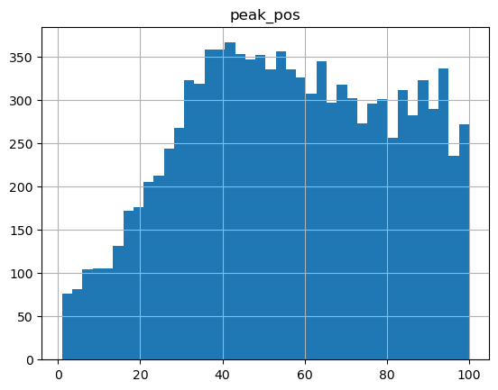

```python
max_performer_peak.hist(bins=40)
```

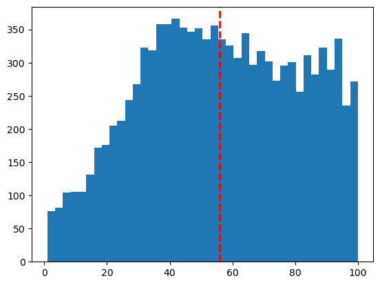

```python
max_performer_peak_pos_mean = int(max_performer_peak_pos_mean.iloc[0,0])
plt.axvline(max_performer_peak_pos_mean, color='r', linestyle='dashed', linewidth=2, label='Mean')
plt.hist(data=max_performer_peak, x='peak_pos', bins=40);
# hah - i have to use plt. convention instead of calling hist() directly from data frame
```

```python
max_performer_peak.sort_values(by='peak_pos', ascending = True)
```

|  | performer | peak_pos |
| --- | --- | --- |
| 5936 | Mariah Carey & Boyz II Men | 1.0 |
| 7383 | R. Kelly & Celine Dion | 1.0 |
| 10071 | Travis Scott Featuring Young Thug & M.I.A. | 1.0 |
| 5212 | Lady Gaga & Ariana Grande | 1.0 |
| 9789 | The Weeknd & Ariana Grande | 1.0 |
| ... | ... | ... |
| 505 | Art Mooney And His Orchestra | 100.0 |
| 172 | A.B. Skhy | 100.0 |
| 9775 | The Vontastics | 100.0 |
| 9871 | ThxSoMch | 100.0 |
| 9706 | The Texans | 100.0 |

10746 rows × 2 columns

Let's take out the one-hit wonders i did that below, but lost the true number of wks_on_chart cuz I didn't add a new column with the counts to preserve the true wks_on_chart values in the df do before that, let's add a column that counts the times a performer/title were on the charts and add a column to the df with those counts

```python
df2
```

|  | chart_week | current_week | title | performer | last_week | peak_pos | wks_on_chart |
| --- | --- | --- | --- | --- | --- | --- | --- |
| 0 | 2022-01-01 | 1 | All I Want For Christmas Is You | Mariah Carey | 1.0 | 1 | 50 |
| 1 | 2022-01-01 | 2 | Rockin' Around The Christmas Tree | Brenda Lee | 2.0 | 2 | 44 |
| 2 | 2022-01-01 | 3 | Jingle Bell Rock | Bobby Helms | 4.0 | 3 | 41 |
| 3 | 2022-01-01 | 4 | A Holly Jolly Christmas | Burl Ives | 5.0 | 4 | 25 |
| 4 | 2022-01-01 | 5 | Easy On Me | Adele | 3.0 | 1 | 11 |
| ... | ... | ... | ... | ... | ... | ... | ... |
| 341495 | 2021-11-13 | 96 | Lets Go Brandon | Loza Alexander | 38.0 | 38 | 3 |
| 341496 | 2021-11-13 | 97 | Just About Over You | Priscilla Block | 95.0 | 95 | 4 |
| 341497 | 2021-11-13 | 98 | To Be Loved By You | Parker McCollum | 96.0 | 96 | 2 |
| 341498 | 2021-11-13 | 99 | Let's Go Brandon | Bryson Gray Featuring Tyson James & Chandler C... | 28.0 | 28 | 2 |
| 341499 | 2021-11-13 | 100 | Ghost Town | Benson Boone | NaN | 100 | 1 |

341500 rows × 7 columns

```python
df2gb2 = df2.groupby(['performer', 'title'], as_index=False).agg({'wks_on_chart': 'mean', 'peak_pos': 'mean'})
# looks like this removes fields not in the .agg function
#df2gb2['new col'] = df2gb2.groupby(['performer']).count()
#
df2gb2
```

|  | performer | title | wks_on_chart | peak_pos |
| --- | --- | --- | --- | --- |
| 0 | "Groove" Holmes | Misty | 6.0 | 62.727273 |
| 1 | "Groove" Holmes | What Now My Love | 2.0 | 97.333333 |
| 2 | "Little" Jimmy Dickens | May The Bird Of Paradise Fly Up Your Nose | 5.5 | 37.700000 |
| 3 | "Pookie" Hudson | I Know I Know | 1.0 | 96.000000 |
| 4 | "Weird Al" Yankovic | Amish Paradise | 8.5 | 54.625000 |
| ... | ... | ... | ... | ... |
| 31047 | will.i.am & Nicki Minaj | Check It Out | 8.0 | 33.200000 |
| 31048 | will.i.am Featuring Justin Bieber | #thatPOWER | 8.5 | 24.812500 |
| 31049 | will.i.am Featuring Mick Jagger & Jennifer Lopez | T.H.E (The Hardest Ever) | 4.5 | 36.000000 |
| 31050 | will.i.am Featuring Miley Cyrus | Fall Down | 1.0 | 58.000000 |
| 31051 | will.i.am Featuring Miley Cyrus, French Montan... | Feelin' Myself | 1.5 | 96.000000 |

31052 rows × 4 columns

```python
df2gb2['hit_count'] = df2gb2.groupby(['performer'])['title'].transform('count')
df2gb2
```

|  | performer | title | wks_on_chart | peak_pos | hit_count |
| --- | --- | --- | --- | --- | --- |
| 0 | "Groove" Holmes | Misty | 6.0 | 62.727273 | 2 |
| 1 | "Groove" Holmes | What Now My Love | 2.0 | 97.333333 | 2 |
| 2 | "Little" Jimmy Dickens | May The Bird Of Paradise Fly Up Your Nose | 5.5 | 37.700000 | 1 |
| 3 | "Pookie" Hudson | I Know I Know | 1.0 | 96.000000 | 1 |
| 4 | "Weird Al" Yankovic | Amish Paradise | 8.5 | 54.625000 | 11 |
| ... | ... | ... | ... | ... | ... |
| 31047 | will.i.am & Nicki Minaj | Check It Out | 8.0 | 33.200000 | 1 |
| 31048 | will.i.am Featuring Justin Bieber | #thatPOWER | 8.5 | 24.812500 | 1 |
| 31049 | will.i.am Featuring Mick Jagger & Jennifer Lopez | T.H.E (The Hardest Ever) | 4.5 | 36.000000 | 1 |
| 31050 | will.i.am Featuring Miley Cyrus | Fall Down | 1.0 | 58.000000 | 1 |
| 31051 | will.i.am Featuring Miley Cyrus, French Montan... | Feelin' Myself | 1.5 | 96.000000 | 1 |

31052 rows × 5 columns

```python
df2gb2 = df2gb2[df2gb2[('hit_count')] > 1]
df2gb2
# this is it! just group by with .agg first to get aggregations like mean and count for all rows
# (it works like windows functions over() command by not collapsing the grouped by columns' rows / removing them from being columns anymore
#, then add a a new col with count of one of the columns originally grouped by (title here) and viola I've got my new column
```

|  | performer | title | wks_on_chart | peak_pos | hit_count |
| --- | --- | --- | --- | --- | --- |
| 0 | "Groove" Holmes | Misty | 6.0 | 62.727273 | 2 |
| 1 | "Groove" Holmes | What Now My Love | 2.0 | 97.333333 | 2 |
| 4 | "Weird Al" Yankovic | Amish Paradise | 8.5 | 54.625000 | 11 |
| 5 | "Weird Al" Yankovic | Canadian Idiot | 2.0 | 82.000000 | 11 |
| 6 | "Weird Al" Yankovic | Eat It | 6.5 | 18.666667 | 11 |
| ... | ... | ... | ... | ... | ... |
| 31041 | twenty one pilots | Shy Away | 1.0 | 87.000000 | 11 |
| 31042 | twenty one pilots | Stressed Out | 26.5 | 18.615385 | 11 |
| 31043 | twenty one pilots | Tear In My Heart | 4.5 | 82.000000 | 11 |
| 31044 | will.i.am | I Got It From My Mama | 5.0 | 40.888889 | 2 |
| 31045 | will.i.am | It's A New Day | 1.5 | 78.000000 | 2 |

23961 rows × 5 columns

Now I can use the df2gb2 dataframe to do new plots First I'll highlight why the methods below don't work

```python
df2['woc_mean'] = df2.groupby(['performer', 'title'], as_index=False)['wks_on_chart'].transform('mean')
df2['peak_mean'] = df2.groupby(['performer', 'title'], as_index=False)['peak_pos'].transform('mean')
#df2.insert(2, "wks_on_chart_mean", df2gb2.to_numpy(), True)
#df.groupby(["state", "gender"])["last_name"].count()
```

```python
df2
```

|  | chart_week | current_week | title | performer | last_week | peak_pos | wks_on_chart | woc_mean | peak_mean |
| --- | --- | --- | --- | --- | --- | --- | --- | --- | --- |
| 0 | 2022-01-01 | 1 | All I Want For Christmas Is You | Mariah Carey | 1.0 | 1 | 50 | 33.156250 | 8.328125 |
| 1 | 2022-01-01 | 2 | Rockin' Around The Christmas Tree | Brenda Lee | 2.0 | 2 | 44 | 29.649123 | 8.578947 |
| 2 | 2022-01-01 | 3 | Jingle Bell Rock | Bobby Helms | 4.0 | 3 | 41 | 28.654545 | 16.090909 |
| 3 | 2022-01-01 | 4 | A Holly Jolly Christmas | Burl Ives | 5.0 | 4 | 25 | 20.421053 | 10.473684 |
| 4 | 2022-01-01 | 5 | Easy On Me | Adele | 3.0 | 1 | 11 | 16.000000 | 3.161290 |
| ... | ... | ... | ... | ... | ... | ... | ... | ... | ... |
| 341495 | 2021-11-13 | 96 | Lets Go Brandon | Loza Alexander | 38.0 | 38 | 3 | 2.000000 | 40.333333 |
| 341496 | 2021-11-13 | 97 | Just About Over You | Priscilla Block | 95.0 | 95 | 4 | 4.000000 | 89.571429 |
| 341497 | 2021-11-13 | 98 | To Be Loved By You | Parker McCollum | 96.0 | 96 | 2 | 10.500000 | 56.400000 |
| 341498 | 2021-11-13 | 99 | Let's Go Brandon | Bryson Gray Featuring Tyson James & Chandler C... | 28.0 | 28 | 2 | 1.500000 | 28.000000 |
| 341499 | 2021-11-13 | 100 | Ghost Town | Benson Boone | NaN | 100 | 1 | 1.000000 | 100.000000 |

341500 rows × 9 columns

```python
df2['new col'] = df2.groupby(['performer','title'], as_index=False)['title'].transform('count')
df2
# nope this doesn't work b/c when using this method (aggregate a column with group by without using .agg)
#the columns have to be collapsed into rows first and then one of the cols counted by using a wide-open group by without cols being selected
#to do aggregations specifically on (just does it on all fields cuz don't specify a target col for the aggregate function)
# to get the hit count like above
```

|  | chart_week | current_week | title | performer | last_week | peak_pos | wks_on_chart | woc_mean | peak_mean | new col |
| --- | --- | --- | --- | --- | --- | --- | --- | --- | --- | --- |
| 0 | 2022-01-01 | 1 | All I Want For Christmas Is You | Mariah Carey | 1.0 | 1 | 50 | 33.156250 | 8.328125 | 64 |
| 1 | 2022-01-01 | 2 | Rockin' Around The Christmas Tree | Brenda Lee | 2.0 | 2 | 44 | 29.649123 | 8.578947 | 57 |
| 2 | 2022-01-01 | 3 | Jingle Bell Rock | Bobby Helms | 4.0 | 3 | 41 | 28.654545 | 16.090909 | 55 |
| 3 | 2022-01-01 | 4 | A Holly Jolly Christmas | Burl Ives | 5.0 | 4 | 25 | 20.421053 | 10.473684 | 38 |
| 4 | 2022-01-01 | 5 | Easy On Me | Adele | 3.0 | 1 | 11 | 16.000000 | 3.161290 | 31 |
| ... | ... | ... | ... | ... | ... | ... | ... | ... | ... | ... |
| 341495 | 2021-11-13 | 96 | Lets Go Brandon | Loza Alexander | 38.0 | 38 | 3 | 2.000000 | 40.333333 | 3 |
| 341496 | 2021-11-13 | 97 | Just About Over You | Priscilla Block | 95.0 | 95 | 4 | 4.000000 | 89.571429 | 7 |
| 341497 | 2021-11-13 | 98 | To Be Loved By You | Parker McCollum | 96.0 | 96 | 2 | 10.500000 | 56.400000 | 20 |
| 341498 | 2021-11-13 | 99 | Let's Go Brandon | Bryson Gray Featuring Tyson James & Chandler C... | 28.0 | 28 | 2 | 1.500000 | 28.000000 | 2 |
| 341499 | 2021-11-13 | 100 | Ghost Town | Benson Boone | NaN | 100 | 1 | 1.000000 | 100.000000 | 1 |

341500 rows × 10 columns

```python
# Assuming you have a DataFrame called df2
# Group by 'performer' and 'title', and count the occurrences

grouped_df = df2.groupby(['performer', 'title']).count()

# doing a free for all group by on all of the columns without using .agg will collapse the grouped by cols into rows instead of cols
# you'll have to do a reset_index if you do that like the line below

#grouped_df = grouped_df.reset_index()

grouped_df2 = df2

#grouped_df2['hit_count'] = df2.groupby(['performer', 'title'])['title'].transform('count')
#grouped_df2['hit_count'] = grouped_df.groupby(['performer', 'title'])['title'].transform('count')
# line above didn't work b/c title had already been turned into a row

# Create a new column with the count values
#df2['count'] = grouped_df['wks_on_chart']  # Replace 'some_column_name' with the actual column you want to count

grouped_df

# Now 'count' column contains the count of occurrences for each performer and title combination
#grouped_df[grouped_df['wks_on_chart'] > 1]
```

| performer | title | chart_week | current_week | last_week | peak_pos | wks_on_chart | woc_mean | peak_mean | new col |
| --- | --- | --- | --- | --- | --- | --- | --- | --- | --- |
| "Groove" Holmes | Misty | 11 | 11 | 10 | 11 | 11 | 11 | 11 | 11 |
|  | What Now My Love | 3 | 3 | 2 | 3 | 3 | 3 | 3 | 3 |
| "Little" Jimmy Dickens | May The Bird Of Paradise Fly Up Your Nose | 10 | 10 | 9 | 10 | 10 | 10 | 10 | 10 |
| "Pookie" Hudson | I Know I Know | 1 | 1 | 0 | 1 | 1 | 1 | 1 | 1 |
| "Weird Al" Yankovic | Amish Paradise | 16 | 16 | 15 | 16 | 16 | 16 | 16 | 16 |
| ... | ... | ... | ... | ... | ... | ... | ... | ... | ... |
| will.i.am & Nicki Minaj | Check It Out | 15 | 15 | 13 | 15 | 15 | 15 | 15 | 15 |
| will.i.am Featuring Justin Bieber | #thatPOWER | 16 | 16 | 15 | 16 | 16 | 16 | 16 | 16 |
| will.i.am Featuring Mick Jagger & Jennifer Lopez | T.H.E (The Hardest Ever) | 8 | 8 | 6 | 8 | 8 | 8 | 8 | 8 |
| will.i.am Featuring Miley Cyrus | Fall Down | 1 | 1 | 0 | 1 | 1 | 1 | 1 | 1 |
| will.i.am Featuring Miley Cyrus, French Montana, Wiz Khalifa & DJ Mustard | Feelin' Myself | 2 | 2 | 1 | 2 | 2 | 2 | 2 | 2 |

31052 rows × 8 columns

```python
grouped_df2
```

|  | chart_week | current_week | title | performer | last_week | peak_pos | wks_on_chart | woc_mean | peak_mean | new col |
| --- | --- | --- | --- | --- | --- | --- | --- | --- | --- | --- |
| 0 | 2022-01-01 | 1 | All I Want For Christmas Is You | Mariah Carey | 1.0 | 1 | 50 | 33.156250 | 8.328125 | 64 |
| 1 | 2022-01-01 | 2 | Rockin' Around The Christmas Tree | Brenda Lee | 2.0 | 2 | 44 | 29.649123 | 8.578947 | 57 |
| 2 | 2022-01-01 | 3 | Jingle Bell Rock | Bobby Helms | 4.0 | 3 | 41 | 28.654545 | 16.090909 | 55 |
| 3 | 2022-01-01 | 4 | A Holly Jolly Christmas | Burl Ives | 5.0 | 4 | 25 | 20.421053 | 10.473684 | 38 |
| 4 | 2022-01-01 | 5 | Easy On Me | Adele | 3.0 | 1 | 11 | 16.000000 | 3.161290 | 31 |
| ... | ... | ... | ... | ... | ... | ... | ... | ... | ... | ... |
| 341495 | 2021-11-13 | 96 | Lets Go Brandon | Loza Alexander | 38.0 | 38 | 3 | 2.000000 | 40.333333 | 3 |
| 341496 | 2021-11-13 | 97 | Just About Over You | Priscilla Block | 95.0 | 95 | 4 | 4.000000 | 89.571429 | 7 |
| 341497 | 2021-11-13 | 98 | To Be Loved By You | Parker McCollum | 96.0 | 96 | 2 | 10.500000 | 56.400000 | 20 |
| 341498 | 2021-11-13 | 99 | Let's Go Brandon | Bryson Gray Featuring Tyson James & Chandler C... | 28.0 | 28 | 2 | 1.500000 | 28.000000 | 2 |
| 341499 | 2021-11-13 | 100 | Ghost Town | Benson Boone | NaN | 100 | 1 | 1.000000 | 100.000000 | 1 |

341500 rows × 10 columns

```python
# df2['hit_count'] = grouped_df.groupby(['performer'], as_index=False)['performer'].transform('count')
# this gets an error b/c performer has already been turn into a row from a column in the grouped_df dataframe
df2
```

|  | chart_week | current_week | title | performer | last_week | peak_pos | wks_on_chart | woc_mean | peak_mean | new col |
| --- | --- | --- | --- | --- | --- | --- | --- | --- | --- | --- |
| 0 | 2022-01-01 | 1 | All I Want For Christmas Is You | Mariah Carey | 1.0 | 1 | 50 | 33.156250 | 8.328125 | 64 |
| 1 | 2022-01-01 | 2 | Rockin' Around The Christmas Tree | Brenda Lee | 2.0 | 2 | 44 | 29.649123 | 8.578947 | 57 |
| 2 | 2022-01-01 | 3 | Jingle Bell Rock | Bobby Helms | 4.0 | 3 | 41 | 28.654545 | 16.090909 | 55 |
| 3 | 2022-01-01 | 4 | A Holly Jolly Christmas | Burl Ives | 5.0 | 4 | 25 | 20.421053 | 10.473684 | 38 |
| 4 | 2022-01-01 | 5 | Easy On Me | Adele | 3.0 | 1 | 11 | 16.000000 | 3.161290 | 31 |
| ... | ... | ... | ... | ... | ... | ... | ... | ... | ... | ... |
| 341495 | 2021-11-13 | 96 | Lets Go Brandon | Loza Alexander | 38.0 | 38 | 3 | 2.000000 | 40.333333 | 3 |
| 341496 | 2021-11-13 | 97 | Just About Over You | Priscilla Block | 95.0 | 95 | 4 | 4.000000 | 89.571429 | 7 |
| 341497 | 2021-11-13 | 98 | To Be Loved By You | Parker McCollum | 96.0 | 96 | 2 | 10.500000 | 56.400000 | 20 |
| 341498 | 2021-11-13 | 99 | Let's Go Brandon | Bryson Gray Featuring Tyson James & Chandler C... | 28.0 | 28 | 2 | 1.500000 | 28.000000 | 2 |
| 341499 | 2021-11-13 | 100 | Ghost Town | Benson Boone | NaN | 100 | 1 | 1.000000 | 100.000000 | 1 |

341500 rows × 10 columns

```python
grouped_df = grouped_df.reset_index()
# this is the main command you have to do to pop the rows back into columns, but by that time, you've lost
#you're original values so this method really doesn't work in the end
```

```python
grouped_df['hit_count'] = grouped_df.groupby(['performer'], as_index=False)['performer'].transform('count')
grouped_df
```

|  | performer | title | chart_week | current_week | last_week | peak_pos | wks_on_chart | woc_mean | peak_mean | new col | hit_count |
| --- | --- | --- | --- | --- | --- | --- | --- | --- | --- | --- | --- |
| 0 | "Groove" Holmes | Misty | 11 | 11 | 10 | 11 | 11 | 11 | 11 | 11 | 2 |
| 1 | "Groove" Holmes | What Now My Love | 3 | 3 | 2 | 3 | 3 | 3 | 3 | 3 | 2 |
| 2 | "Little" Jimmy Dickens | May The Bird Of Paradise Fly Up Your Nose | 10 | 10 | 9 | 10 | 10 | 10 | 10 | 10 | 1 |
| 3 | "Pookie" Hudson | I Know I Know | 1 | 1 | 0 | 1 | 1 | 1 | 1 | 1 | 1 |
| 4 | "Weird Al" Yankovic | Amish Paradise | 16 | 16 | 15 | 16 | 16 | 16 | 16 | 16 | 11 |
| ... | ... | ... | ... | ... | ... | ... | ... | ... | ... | ... | ... |
| 31047 | will.i.am & Nicki Minaj | Check It Out | 15 | 15 | 13 | 15 | 15 | 15 | 15 | 15 | 1 |
| 31048 | will.i.am Featuring Justin Bieber | #thatPOWER | 16 | 16 | 15 | 16 | 16 | 16 | 16 | 16 | 1 |
| 31049 | will.i.am Featuring Mick Jagger & Jennifer Lopez | T.H.E (The Hardest Ever) | 8 | 8 | 6 | 8 | 8 | 8 | 8 | 8 | 1 |
| 31050 | will.i.am Featuring Miley Cyrus | Fall Down | 1 | 1 | 0 | 1 | 1 | 1 | 1 | 1 | 1 |
| 31051 | will.i.am Featuring Miley Cyrus, French Montan... | Feelin' Myself | 2 | 2 | 1 | 2 | 2 | 2 | 2 | 2 | 1 |

31052 rows × 11 columns

```python
df2[df2['performer']=='"Groove" Holmes']
```

|  | chart_week | current_week | title | performer | last_week | peak_pos | wks_on_chart | woc_mean | peak_mean | new col |
| --- | --- | --- | --- | --- | --- | --- | --- | --- | --- | --- |
| 51899 | 1966-06-25 | 100 | Misty | "Groove" Holmes | NaN | 100 | 1 | 6.0 | 62.727273 | 11 |
| 51984 | 1966-07-02 | 85 | Misty | "Groove" Holmes | 100.0 | 85 | 2 | 6.0 | 62.727273 | 11 |
| 52083 | 1966-07-09 | 84 | Misty | "Groove" Holmes | 85.0 | 84 | 3 | 6.0 | 62.727273 | 11 |
| 52181 | 1966-07-16 | 82 | Misty | "Groove" Holmes | 84.0 | 82 | 4 | 6.0 | 62.727273 | 11 |
| 52263 | 1966-07-23 | 64 | Misty | "Groove" Holmes | 82.0 | 64 | 5 | 6.0 | 62.727273 | 11 |
| 52349 | 1966-07-30 | 50 | Misty | "Groove" Holmes | 64.0 | 50 | 6 | 6.0 | 62.727273 | 11 |
| 52446 | 1966-08-06 | 47 | Misty | "Groove" Holmes | 50.0 | 47 | 7 | 6.0 | 62.727273 | 11 |
| 52545 | 1966-08-13 | 46 | Misty | "Groove" Holmes | 47.0 | 46 | 8 | 6.0 | 62.727273 | 11 |
| 52643 | 1966-08-20 | 44 | Misty | "Groove" Holmes | 46.0 | 44 | 9 | 6.0 | 62.727273 | 11 |
| 52747 | 1966-08-27 | 48 | Misty | "Groove" Holmes | 44.0 | 44 | 10 | 6.0 | 62.727273 | 11 |
| 52857 | 1966-09-03 | 58 | Misty | "Groove" Holmes | 48.0 | 44 | 11 | 6.0 | 62.727273 | 11 |
| 53297 | 1966-10-01 | 98 | What Now My Love | "Groove" Holmes | NaN | 98 | 1 | 2.0 | 97.333333 | 3 |
| 53397 | 1966-10-08 | 98 | What Now My Love | "Groove" Holmes | 98.0 | 98 | 2 | 2.0 | 97.333333 | 3 |
| 53495 | 1966-10-15 | 96 | What Now My Love | "Groove" Holmes | 98.0 | 96 | 3 | 2.0 | 97.333333 | 3 |

```python
#grouped_df[grouped_df['performer']=='"Weird Al" Yankovic']
#df2[df2['performer']=='"Groove" Holmes']
grouped_df.dtypes
```

```
performer       object
title           object
chart_week       int64
current_week     int64
last_week        int64
peak_pos         int64
wks_on_chart     int64
woc_mean         int64
peak_mean        int64
new col          int64
hit_count        int64
dtype: object
```

```python
df2.dtypes
```

```
chart_week       object
current_week      int64
title            object
performer        object
last_week       float64
peak_pos          int64
wks_on_chart      int64
woc_mean        float64
peak_mean       float64
new col           int64
dtype: object
```

```python
# grouped_df[grouped_df[('hit_count')] > 1]
grouped_df_noOneHits = grouped_df[grouped_df[('hit_count')] > 1]
grouped_df_noOneHits
# yes this is what i want but do it on df2 instead to not lose the peak_pos & woc means when determining the hit_count col?
```

|  | performer | title | chart_week | current_week | last_week | peak_pos | wks_on_chart | woc_mean | peak_mean | new col | hit_count |
| --- | --- | --- | --- | --- | --- | --- | --- | --- | --- | --- | --- |
| 0 | "Groove" Holmes | Misty | 11 | 11 | 10 | 11 | 11 | 11 | 11 | 11 | 2 |
| 1 | "Groove" Holmes | What Now My Love | 3 | 3 | 2 | 3 | 3 | 3 | 3 | 3 | 2 |
| 4 | "Weird Al" Yankovic | Amish Paradise | 16 | 16 | 15 | 16 | 16 | 16 | 16 | 16 | 11 |
| 5 | "Weird Al" Yankovic | Canadian Idiot | 3 | 3 | 2 | 3 | 3 | 3 | 3 | 3 | 11 |
| 6 | "Weird Al" Yankovic | Eat It | 12 | 12 | 11 | 12 | 12 | 12 | 12 | 12 | 11 |
| ... | ... | ... | ... | ... | ... | ... | ... | ... | ... | ... | ... |
| 31041 | twenty one pilots | Shy Away | 1 | 1 | 0 | 1 | 1 | 1 | 1 | 1 | 11 |
| 31042 | twenty one pilots | Stressed Out | 52 | 52 | 49 | 52 | 52 | 52 | 52 | 52 | 11 |
| 31043 | twenty one pilots | Tear In My Heart | 8 | 8 | 6 | 8 | 8 | 8 | 8 | 8 | 11 |
| 31044 | will.i.am | I Got It From My Mama | 9 | 9 | 8 | 9 | 9 | 9 | 9 | 9 | 2 |
| 31045 | will.i.am | It's A New Day | 2 | 2 | 0 | 2 | 2 | 2 | 2 | 2 | 2 |

23961 rows × 11 columns

```python
# df2 = df2[grouped_df[('hit_count')] > 1]
df2
```

|  | chart_week | current_week | title | performer | last_week | peak_pos | wks_on_chart | woc_mean | peak_mean | new col |
| --- | --- | --- | --- | --- | --- | --- | --- | --- | --- | --- |
| 0 | 2022-01-01 | 1 | All I Want For Christmas Is You | Mariah Carey | 1.0 | 1 | 50 | 33.156250 | 8.328125 | 64 |
| 1 | 2022-01-01 | 2 | Rockin' Around The Christmas Tree | Brenda Lee | 2.0 | 2 | 44 | 29.649123 | 8.578947 | 57 |
| 2 | 2022-01-01 | 3 | Jingle Bell Rock | Bobby Helms | 4.0 | 3 | 41 | 28.654545 | 16.090909 | 55 |
| 3 | 2022-01-01 | 4 | A Holly Jolly Christmas | Burl Ives | 5.0 | 4 | 25 | 20.421053 | 10.473684 | 38 |
| 4 | 2022-01-01 | 5 | Easy On Me | Adele | 3.0 | 1 | 11 | 16.000000 | 3.161290 | 31 |
| ... | ... | ... | ... | ... | ... | ... | ... | ... | ... | ... |
| 341495 | 2021-11-13 | 96 | Lets Go Brandon | Loza Alexander | 38.0 | 38 | 3 | 2.000000 | 40.333333 | 3 |
| 341496 | 2021-11-13 | 97 | Just About Over You | Priscilla Block | 95.0 | 95 | 4 | 4.000000 | 89.571429 | 7 |
| 341497 | 2021-11-13 | 98 | To Be Loved By You | Parker McCollum | 96.0 | 96 | 2 | 10.500000 | 56.400000 | 20 |
| 341498 | 2021-11-13 | 99 | Let's Go Brandon | Bryson Gray Featuring Tyson James & Chandler C... | 28.0 | 28 | 2 | 1.500000 | 28.000000 | 2 |
| 341499 | 2021-11-13 | 100 | Ghost Town | Benson Boone | NaN | 100 | 1 | 1.000000 | 100.000000 | 1 |

341500 rows × 10 columns

```python
#grouped_df_noOneHits['wks_on_chart_mean'] =
#grouped_df_noOneHits.groupby(['performer'], as_index=False).agg({'wks_on_chart': 'mean'})

grouped_df_noOneHits['woc_mean'] = grouped_df_noOneHits.groupby(['performer'], as_index=False)['wks_on_chart'].transform('mean')

#grouped_df_noOneHits['peak_mean'] = grouped_df_noOneHits.groupby(['performer'], as_index=False)['peak_pos'].transform('mean')
# nope can't do mean peak_pos cuz the values now are just a count of the grouped performer/title records
#to get peak, I'd have to get it before the count

grouped_df_noOneHits

# yeah, no this doesn't work - the orig values are all gone
```

|  | performer | title | chart_week | current_week | last_week | peak_pos | wks_on_chart | woc_mean | peak_mean | new col | hit_count |
| --- | --- | --- | --- | --- | --- | --- | --- | --- | --- | --- | --- |
| 0 | "Groove" Holmes | Misty | 11 | 11 | 10 | 11 | 11 | 7.000000 | 11 | 11 | 2 |
| 1 | "Groove" Holmes | What Now My Love | 3 | 3 | 2 | 3 | 3 | 7.000000 | 3 | 3 | 2 |
| 4 | "Weird Al" Yankovic | Amish Paradise | 16 | 16 | 15 | 16 | 16 | 8.272727 | 16 | 16 | 11 |
| 5 | "Weird Al" Yankovic | Canadian Idiot | 3 | 3 | 2 | 3 | 3 | 8.272727 | 3 | 3 | 11 |
| 6 | "Weird Al" Yankovic | Eat It | 12 | 12 | 11 | 12 | 12 | 8.272727 | 12 | 12 | 11 |
| ... | ... | ... | ... | ... | ... | ... | ... | ... | ... | ... | ... |
| 31041 | twenty one pilots | Shy Away | 1 | 1 | 0 | 1 | 1 | 14.454545 | 1 | 1 | 11 |
| 31042 | twenty one pilots | Stressed Out | 52 | 52 | 49 | 52 | 52 | 14.454545 | 52 | 52 | 11 |
| 31043 | twenty one pilots | Tear In My Heart | 8 | 8 | 6 | 8 | 8 | 14.454545 | 8 | 8 | 11 |
| 31044 | will.i.am | I Got It From My Mama | 9 | 9 | 8 | 9 | 9 | 5.500000 | 9 | 9 | 2 |
| 31045 | will.i.am | It's A New Day | 2 | 2 | 0 | 2 | 2 | 5.500000 | 2 | 2 | 2 |

23961 rows × 11 columns

```python
# wow so see, what's with the come together/something line? why isn't it hashed with got to get you into my life, which is also 16 weeks?
# remember to look it up online later - stay on target!
maxes2 = max3[max3['performer']=='The Beatles']
print (maxes2)
```

```
         performer                             title  wks_on_chart
25563  The Beatles                   Twist And Shout            26
25525  The Beatles                          Hey Jude            19
25514  The Beatles           Come Together/Something            16
25522  The Beatles       Got To Get You Into My Life            16
25551  The Beatles                     She Loves You            15
...            ...                               ...           ...
25565  The Beatles                      What Goes On             2
25539  The Beatles                      Now And Then             2
25561  The Beatles                   There's A Place             1
25559  The Beatles                   The Inner Light             1
25533  The Beatles  I'm Happy Just To Dance With You             1

[66 rows x 3 columns]
```

```python
# max3.iloc[0].wks_on_chart
allmaxweeks = max3.iloc[0].wks_on_chart
allmaxperformer = max3.iloc[0].performer
allmaxtitle = max3.iloc[0].title
print(allmaxweeks)
print(allmaxperformer)
print(allmaxtitle)
```

```
91
Glass Animals
Heat Waves
```

```python
maxes2.iloc[0]
bmaxweeks = maxes2.iloc[0].wks_on_chart
#bmaxperformer = maxes2.iloc[0].performer
bmaxtitle = maxes2.iloc[0].title
print(bmaxweeks)
print(bmaxtitle)
```

```
26
Twist And Shout
```

```python
#Here's another way of doing it, but I couldn't use that type of method - no var assignment of iloc without the wks_on_chart being specifically targeted - in the bar chart
beatlesmaxweeks = maxes2.iloc[0]
print (beatlesmaxweeks.wks_on_chart)
```

```
26
```

```python
# iloc is my friend...that's exactly what I want
# so now....

# df[df['performer'] == 'The Beatles']
#alltogethernow = max3[max3.iloc[0] > maxes2.iloc[0]]
#print ([alltogethernow])

import numpy as np
```

```python
print (max3)
```

```
                                    performer                 title  \
10432                           Glass Animals            Heat Waves
28565                              The Weeknd       Blinding Lights
11692                         Imagine Dragons           Radioactive
416                                AWOLNATION                  Sail
7823                                 Dua Lipa            Levitating
...                                       ...                   ...
22214                            Robin Thicke          Get Her Back
28645  The White Buffalo & The Forest Rangers  Come Join The Murder
10589                               Glee Cast        Sweet Caroline
10590                               Glee Cast            Take A Bow
9842                                   Future         Super Trapper

       wks_on_chart
10432            91
28565            90
11692            87
416              79
7823             77
...             ...
22214             1
28645             1
10589             1
10590             1
9842              1

[31052 rows x 3 columns]
```

```python
np.where((max3['wks_on_chart'] > bmaxweeks), (max3['performer'], max3['title'], max3['wks_on_chart']), np.nan)
```

```
array([['Glass Animals', 'The Weeknd', 'Imagine Dragons', ..., nan, nan,
        nan],
       ['Heat Waves', 'Blinding Lights', 'Radioactive', ..., nan, nan,
        nan],
       [91, 90, 87, ..., nan, nan, nan]], dtype=object)
```

```python
# df['que'] =
results = np.where((max3['wks_on_chart'] > bmaxweeks), (max3['performer'], max3['title'], max3['wks_on_chart']), np.nan)
print (results)
```

```
[['Glass Animals' 'The Weeknd' 'Imagine Dragons' ... nan nan nan]
 ['Heat Waves' 'Blinding Lights' 'Radioactive' ... nan nan nan]
 [91 90 87 ... nan nan nan]]
```

```python
# Initialize arrays
#A = np.array([2, 1, 5, 4])
#B = np.array([3, 4, 7, 8])
#C = np.array([8, 6, 0, 3])

# Vertically stack arrays
# output = np.vstack((A, B, C))
# print(output)#hmm maybe it is already stacked into an array
#let's try to dump it into a dataframe
#df3 = pd.DataFrame(results).swapaxes('index','columns')
# above replaced with below
df3 = pd.DataFrame(results).transpose()
print (df3)
```

```
                     0                1    2
0        Glass Animals       Heat Waves   91
1           The Weeknd  Blinding Lights   90
2      Imagine Dragons      Radioactive   87
3           AWOLNATION             Sail   79
4             Dua Lipa       Levitating   77
...                ...              ...  ...
31047              NaN              NaN  NaN
31048              NaN              NaN  NaN
31049              NaN              NaN  NaN
31050              NaN              NaN  NaN
31051              NaN              NaN  NaN

[31052 rows x 3 columns]
```

```python
df3.columns.values
```

```
array([0, 1, 2], dtype=int64)
```

```python
df3.rename(columns={0:"Performer",1:"Title", 2:"Wks_On_Chart"}, errors="raise")
```

|  | Performer | Title | Wks_On_Chart |
| --- | --- | --- | --- |
| 0 | Glass Animals | Heat Waves | 91 |
| 1 | The Weeknd | Blinding Lights | 90 |
| 2 | Imagine Dragons | Radioactive | 87 |
| 3 | AWOLNATION | Sail | 79 |
| 4 | Dua Lipa | Levitating | 77 |
| ... | ... | ... | ... |
| 31047 | NaN | NaN | NaN |
| 31048 | NaN | NaN | NaN |
| 31049 | NaN | NaN | NaN |
| 31050 | NaN | NaN | NaN |
| 31051 | NaN | NaN | NaN |

31052 rows × 3 columns